# Entrega Final

2023-05-16

## Tema

El presente estudio se propone analizar la relación entre el nivel educativo (variable independiente) y la violencia física hacia la mujer ejercida por su pareja sentimental (dependiente). En este sentido, se presenta como pregunta preliminar ¿De qué manera el nivel educativo alcanzado por la mujer influye en la violencia física ejercida por su pareja sentimental?

## Justificación

En los últimos meses, se ha podido evidenciar los altos niveles de violencia que sufren las mujeres, principalmente, por parte de sus parejas sentimentales. Desde altas tasas de feminicidios hasta altas tasas de denuncias por agresión sexual, representan una problematica dia en la vida de las mujeres peruanas. Sin embargo, se ha podido observar que a partir de una mayor autonomía y empoderamiento, muchas mujeres que sufren esta violencia han podido liberarse de esta. Principalmente, actividades como la educación y el trabajo logran que las mujeres cambien las dinámicas de poder en sus relaciones.  
En este sentido, es importante analizar de qué manera puede influenciar estas actividades en disminuir la violencia que sufren las mujeres. Es así que el presente trabajo se propone indagar en cómo el nivel educativo influye en la violencia física que sufre la mujer por parte de su pareja.

## Fuente de datos

La base de datos analizada es la obtenida a partir de la Encuesta Demográfica y de Salud Familiar (2021). Esta encuesta presenta información sobre las característica de las viviendas y población, el nivel de fecundidad, la situación de la salud reproductiva, conocimientos sobre enfermedades de transmisión sexual, violencia contra las mujeres, entre otros. Es así que, a partir de sus diferentes temas de información, se aplicaron tres cuestionarios diferentes: cuestionario del hogar, cuestionario individual de la mujer, cuestionario de salud.

La presente encuesta tiene como población objetivo viviendas particulares y sus miembros a nivel nacional. Si bien tiene en cuenta a todos los miembros del hogar de la vivienda, su población principal es el grupo de mujeres de 12 a 49 años de edad. Es así que ,de la muestra de 36 760 viviendas seleccionadas, se obtuvieron 36 714 mujeres entrevistadas.

En relación al método de recolección de datos, se utilizó la entrevista directa (presencial) y entrevista telefónica realizadas por encuestadores debidamente capacitados. También, el instrumento de recolección fue a través de un dispositivo móvil: tablet.

En la presente investigación, se desea analizar las variables nivel educativo y violencia física ejercida por la pareja sentimental por lo que el estudio se centrará en el cuestionario individual de la mujer. En este sentido, nuestra base de datos y los módulos seleccionados se concentrarán en este.

Los módulos que se utilizaran son los siguientes:

- 1631 (datos básicos del MEF, subdividida en las bases REC91 y REC0111)  
  En la base de datos REC0111, se puede encontrar información relacionada a la edad de la entrevistada, lugar de residencia e índice de riqueza.  
  En la base de datos REC91, se puede encontrar información relacionada al nivel educativo alcanzado y la lengua materna.
- 1637 (mortalidad materna - violencia familiar en la base REC84DV) En la presente base de datos, se puede encontrar información relacionada a los distintos tipos de violencia que puede sufrir las mujeres entrevistadas (psicológica, física y sexual). Se ha decidido seleccionar la sección de violencia doméstica.

## Descripción de las variables

En la presente investigación, se desea conocer la influencia del nivel educativo de la mujer en la violencia física ejercida por la pareja sentimental. Por esta razón, se han seleccionado 5 variables que nos ayuden a conocer más sobre la población de estudio y la problemática a investigar.

## Variable dependiente: Índice de violencia

La variable que se describe es la variable índice de violencia física, la cual se presenta con el nombre de violencia en la base de datos. Este índice se creó a partir de la pregunta 1005 que se presenta en la sección violencia doméstica. Esta pregunta busca saber si la entrevistada sufrió algún tipo de violencia física (retorcijón, jalón, golpe, puñetazos, entre otros) por parte de su pareja sentimental. Es así que la pregunta se subdivide en 8 sub preguntas en las cuales se especifica el tipo de violencia física que ha sufrido la mujer entrevistada.

Se ha decidido agrupar estas preguntas en un índice de violencia física, el cual se encuentra en un rango del 0 al 1. En este sentido, un índice de violencia física de 0 significa que la mujer no ha sufrido ningún tipo de violencia física ( jalones, golpes, puñaladas,etc), mientras que un índice de violencia física de 1 significa que la mujer ha sufrido un conjunto de distintos tipos de violencia física.

A continuación, se presentara un tabla con las principales medidas centrales:

| Min | Max | Media | Mediana | Desv | Varianza |
| --- | --- | --- | --- | --- | --- |
| 0 | 1 | 0.06 | 0 | 0.14 | 0.02 |

A partir de las medidas centrales:

|  | x |
| --- | --- |
| 10% | 0.00 |
| 20% | 0.00 |
| 30% | 0.00 |
| 40% | 0.00 |
| 50% | 0.00 |
| 60% | 0.00 |
| 70% | 0.00 |
| 80% | 0.08 |
| 90% | 0.24 |
| 100% | 1.00 |

A partir de esta tabla:

- Se observa que el 20% de las entrevistadas ha sufrido al menos un tipo de violencia física por parte de su pareja, mientras que la mayoría no ha sufrido ningún tipo de violencia física siendo su nivel 0.
- A partir de los percentiles 8 y 9, los niveles de violencia física comenzaron a ser más dispersos.

### Gráfico:

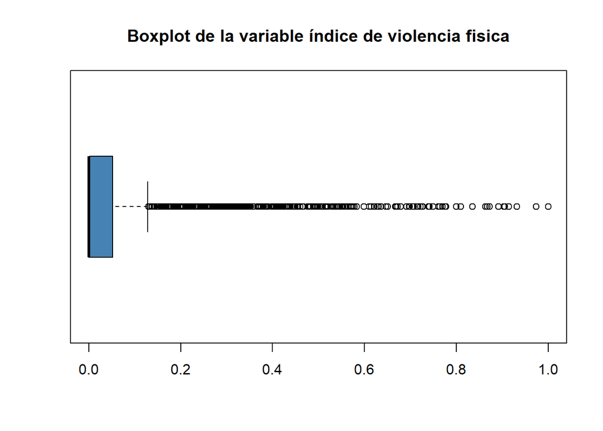

## Edad

La variable que se describe es la variable edad, la cual se presenta con el mismo nombre en nuestra base de datos. La presente variable es numérica.

A partir de las medidas centrales:

- Se observa que el rango de edad se encuentra entre los 15 a 49 años.
- Se observa que la media (32,49 años) es mayor a la mediana (32 años). Estos datos nos indicarían que existe un distribución sesgada a la derecha, lo cual significa que los valores más altos arrastrando hacia a la derecha a la media.
- A partir de estos indicadores, calculamos la desviación estándar (7.61) y la varianza (57.9), los cuales indican que se presenta una dispersión moderada en la presente variable.

Tabla de percentiles:

|  | x |
| --- | --- |
| 10% | 23 |
| 20% | 26 |
| 30% | 28 |
| 40% | 30 |
| 50% | 32 |
| 60% | 34 |
| 70% | 37 |
| 80% | 39 |
| 90% | 43 |
| 100% | 49 |

### Gráfico:

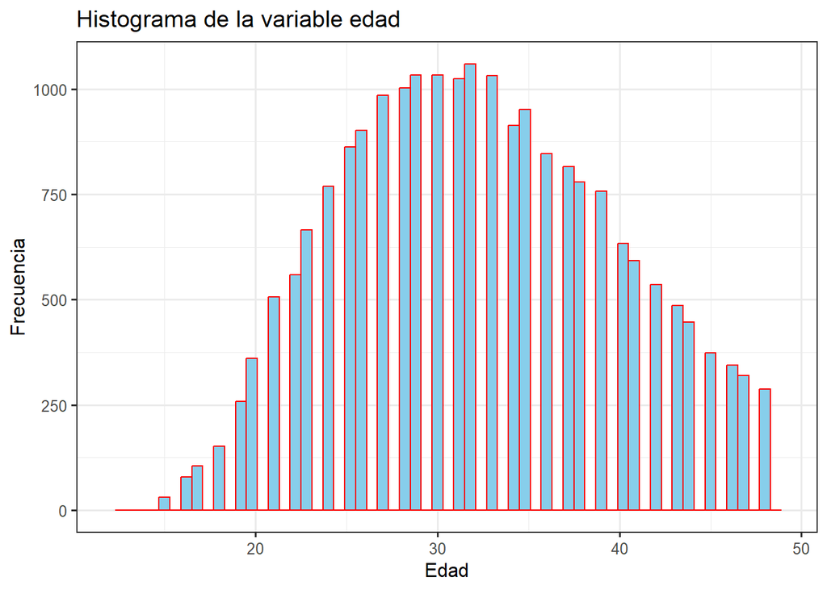

## Nivel educativo

La variable que se describe es la variable nivel educativo, la cual se presenta con el nombre de educa en la base de datos. La presente variable es nominal con 6 etiquetas (Inicial/Pre-escolar, Primario, Secundario, Superior no universitario, Superior universitario, Posgrado)

Se ha realizado un cuadro de porcentajes:

| Nivel educativo | Porcentaje |
| --- | --- |
| Posgrado | 1.04 |
| Inicial | 1.61 |
| Superior universitario | 13.03 |
| Superior no universitario | 17.80 |
| Primario | 20.02 |
| Secundario | 46.50 |

A partir de los datos anteriores, se puede observar:

- Los niveles educativos que presentan mayor porcentaje son los niveles primario y secundario siendo 20.02% y 46.50% respectivamente.
- Los niveles educativos que presentan menor porcentaje son los niveles inicial y posgrado siendo 1.61% y 1.04% respectivamente.

### Gráfico:

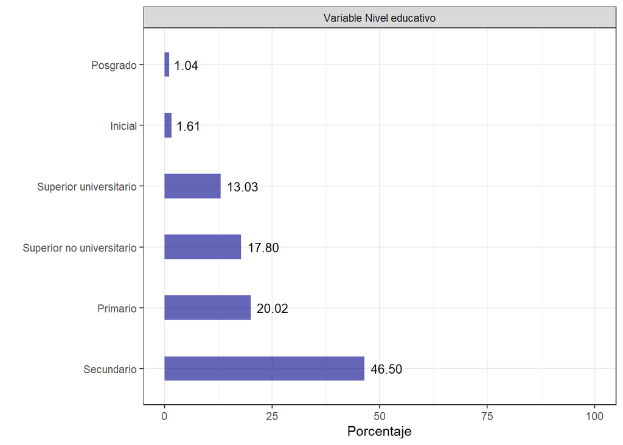

## Lengua Materna

La variable que se describe es la variable lengua materna, la cual se presenta con el nombre de lengua en la base de datos. La presente variable es nominal con 2 etiquetas ( Castellano y No castellano).

Se ha realizado un cuadro de porcentajes:

| Lengua Materna | Porcentaje |
| --- | --- |
| No castellano | 23.09 |
| Castellano | 76.91 |

A partir de la tabla, se puede observar que la mayor parte de las mujeres encuestadas (76.91%) tiene como lengua materna el castellano, por lo que pueden acceder con mayor facilidad a diferentes servicios, entre los que se encuentra la educación. Por otro lado, un poco más del 20% de las encuestadas (23.09%) tiene una lengua materna distinta al castellano. En este porcentaje podemos encontrar lenguas como Quechua, Aymara, Ashaninka, Awajun, Shipibo, las cuales pueden disminuir el acceso a servicios como la educación. Esto se debe al poco contenido educativo que se ha producido en otras lenguas distintas al castellano, especialmente, en la educación universitaria superior, en la que existen contadas investigaciones realizadas en quechua o aimara.

### Gráfico:

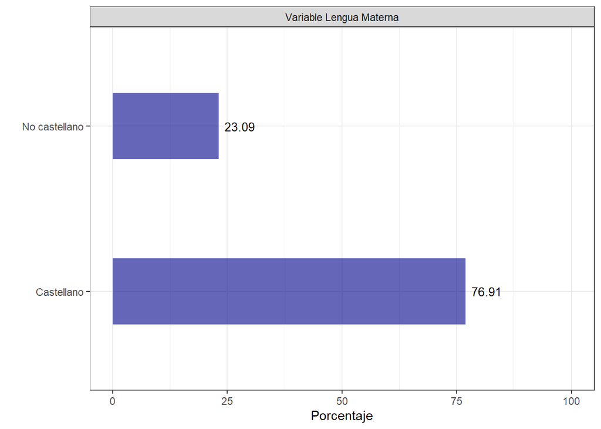

## Tipo de residencia

La variable que se describe es la variable tipo de residencia, la cual se presenta con el nombre de residencia en la base de datos. La presente variable es nominal dicotómica con etiquetas urbano y rural.

Se ha realizado un cuadro de porcentaje:

| Lugar de residencia | Porcentaje |
| --- | --- |
| Rural | 33.29 |
| Urbano | 66.71 |

A partir de la tabla, se puede observar: La mayoría de las entrevistadas (66.71%) residen en zonas urbanas. Estos datos nos indican que más de la mitad de entrevistadas (66.71%) residen en zonas urbanas, mientras que un tercio del total reside en zonas rurales (33.29%). Esto podría deberse a que las zonas urbanas presentan más accesos a servicios como educación, empleo y salud, lo cual podría permitir una mejor calidad de vida. En este sentido, mayor cantidad de personas se trasladaron a estas zonas para acceder más fácilmente a estos servicios.

### Gráfico:

[figure not shown]

## Índice de riqueza

La variable que se describe es la variable índice de riqueza, la cual se presenta con el nombre de riqueza en la base de datos. La presente variable es nominal con 5 etiquetas (El más pobre, Pobre, Medio , Rico y Más rico).

Se ha realizado un cuadro de porcentaje:

| Discriminacion | Porcentaje |
| --- | --- |
| Más rico | 9.30 |
| Rico | 14.08 |
| Medio | 19.51 |
| Pobre | 26.64 |
| El más pobre | 30.48 |

A partir de la tabla, se puede observar: - El índice de riqueza con mayor porcentaje es el más pobre siendo 30.48% - Los índices de riqueza que siguen a este son el pobre y el medio siendo 26.64% y 19.51%, respectivamente. - El índice de riqueza más rico se concentra en menos del 10%.

Estos datos nos indican que más del 50% de entrevistadas se encuentran en una condición de pobreza (26.64%) y pobreza extrema (30.48%). Estas condiciones de riquezas podrían aumentar las desigualdades en relación de accesos a servicios. Por otro lado, menos del 10 % de las entrevistadas pertenece al nivel más rico de riqueza, lo cual les permitiría mayor cantidad de oportunidades. Esto podría significar un aumento en las libertades de la mujer.

### Gráfico:

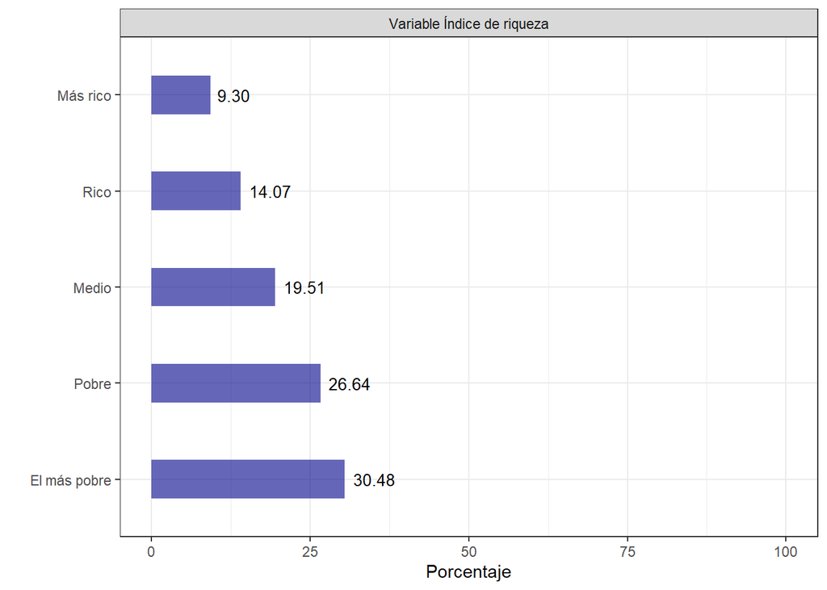

## Análisis Bivariado

A continuación, se realizará una análisis bivariado entre la variable dependiente y cada una de las variables independientes para analizar su relación con esta. A partir de cada cruce que se presentará en las tablas, se realizará una hipótesis sobre la existencia de una relación entre las variables. Seguidamente, se confirmará o negará la hipótesis propuesta.

## Relación entre índice de violencia física y edad

A partir de la base de datos, se ha realizado una tabla cruzada de las variables índice de violencia física y edad. Para lograr construir esta tabla cruzada, se ha decidio agrupar las edades popr cuartiles. Es asi que se ha creado cuatro grupos de edades: 15 - 27 años, 28 - 32 años, 33 - 38 años y 39 - 49 años.

| Rango de edad | mean | min | max |
| --- | --- | --- | --- |
| 15 - 27 años | 0.04 | 0 | 1 |
| 28-32 años | 0.05 | 0 | 1 |
| 33-38 años | 0.07 | 0 | 1 |
| 39-49 años | 0.09 | 0 | 1 |

A partir de la tabla, se puede evidenciar que el índice de violencia varía según el grupo de edades al presentarse una media distinta en cada uno de estos grupos. En este sentido, podemos encontrar las medias más altas en los grupos de mayor edad, mientras que las medias más bajas se encuentran en los grupos de edades menores. Es así que el grupo de 39 - 49 años presenta la media más alta siendo 0.09. Seguido, se presenta el grupo de 33 - 38 años teniendo una media de 0.07. La media más baja se presenta en el grupo de 15 - 27 años de edad, teniendo 0.04.

### Gráfico:

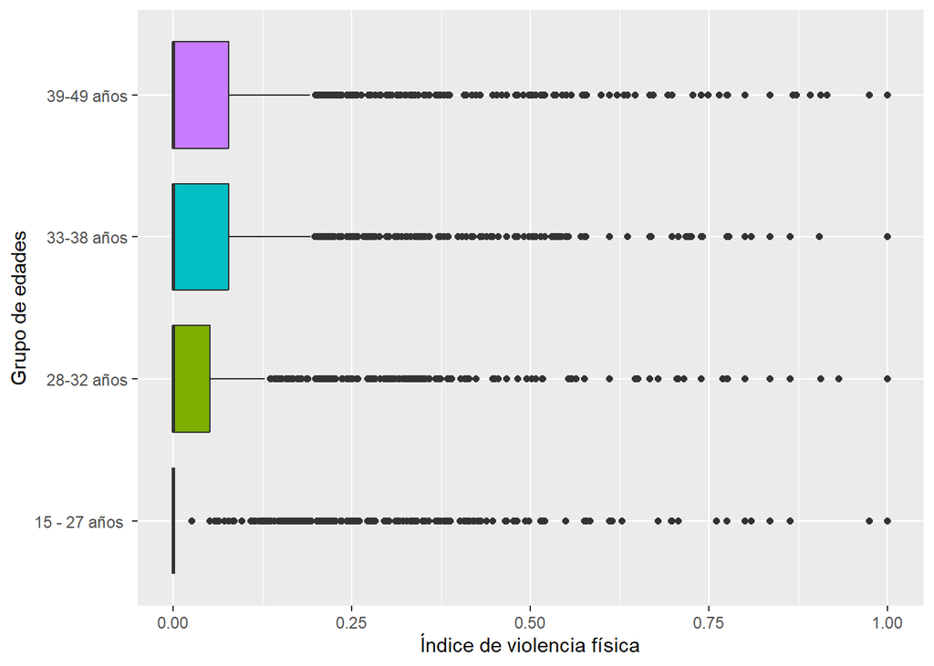

A partir de los cambios identificados, se propone como hipótesis que existe relación significativa entre los estadísticos de las variables índice de violencia física y edad. A continuación, se comprobará la hipótesis propuesta:

```
##
##  Pearson's product-moment correlation
##
## data:  ENDES$violencia and ENDES$edad
## t = 17.574, df = 21795, p-value < 2.2e-16
## alternative hypothesis: true correlation is not equal to 0
## 95 percent confidence interval:
##  0.1050919 0.1312722
## sample estimates:
##       cor
## 0.1182026
```

Con un p-value menor a o.5 (95% de confianza), podemos concluir que existe una correlación estadísticamente significativa entre las variables índice de violencia física y edad. Además, presenta correlación positiva leve (cor= 0.11)

## Relación entre índice de violencia física y nivel educativo

A partir de la base de datos, se ha realizado una tabla cruzada de las variables índice de violencia física y nivel educativo.

| Nivel educativo | mean | min | max |
| --- | --- | --- | --- |
| Inicial | 0.11 | 0 | 1.00 |
| Posgrado | 0.02 | 0 | 0.58 |
| Primario | 0.08 | 0 | 1.00 |
| Secundario | 0.07 | 0 | 1.00 |
| Superior no universitario | 0.05 | 0 | 1.00 |
| Superior universitario | 0.03 | 0 | 1.00 |

### Gráfico:

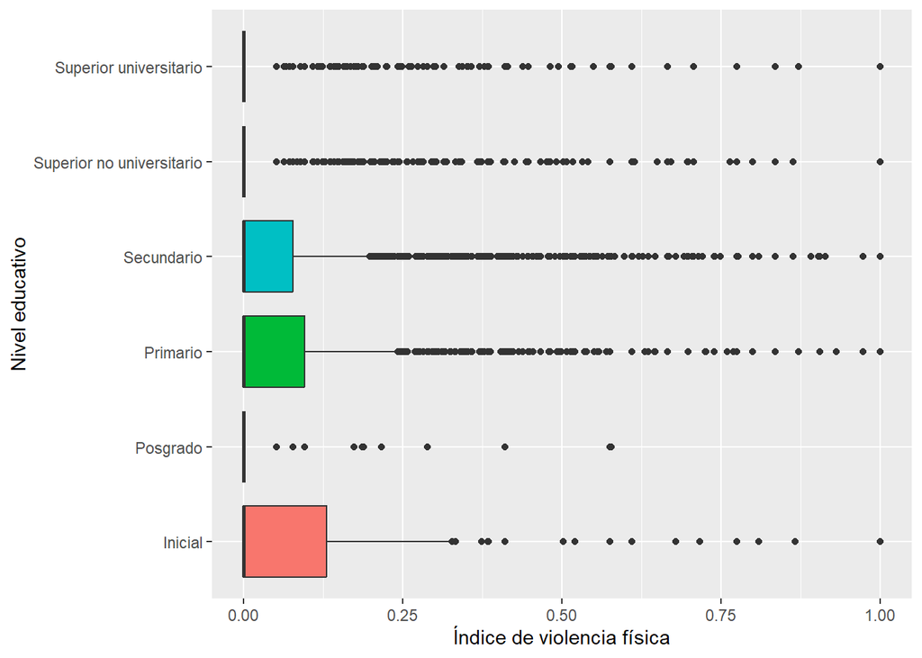

A partir de los cambios identificados, se propone como hipótesis que existe relación significativa entre los estadísticos de las variables índice de violencia física y nivel educativo. A continuación, se comprobará la hipótesis propuesta:

```
##                Df Sum Sq Mean Sq F value Pr(>F)
## educa           5    6.7  1.3427    71.4 <2e-16 ***
## Residuals   21791  409.8  0.0188
## ---
## Signif. codes:  0 '***' 0.001 '**' 0.01 '*' 0.05 '.' 0.1 ' ' 1
```

Con un p-valor(>F) menor a 0.05 (95% de confianza), existe evidencia suficiente para rechazar la hipótesis nula de independencia estadística entre las variables índice de violencia física y el nivel educativo. Por tanto, concluimos que existe una diferencia estadísticamente significativa entre las variables mencionadas.

## Relación entre índice de violencia física y lengua materna

A partir de la base de datos, se ha realizado una tabla cruzada de las variables índice de violencia física y lengua materna.

| Lengua Materna | mean | min | max |
| --- | --- | --- | --- |
| No castellano | 0.09 | 0 | 1 |
| Castellano | 0.05 | 0 | 1 |

A partir de la tabla, se puede observar que el índice de violencia varía según la lengua materna al presentarse medias distintas en cada categoría. Se observa que las mujeres que no tienen la lengua materna castellano presentan un mayor media (0.09 a comparación de la lengua castellano (0.05)). A partir de esta observación, podemos suponer que tener como lengua materna el castellano reduce la posibilidad de tener un mayor índice de violencia física en comparación con lenguas menos habladas. En relación a los mínimos y máximos, estos se mantienen iguales entre las dos categorías.

### Gráfico:

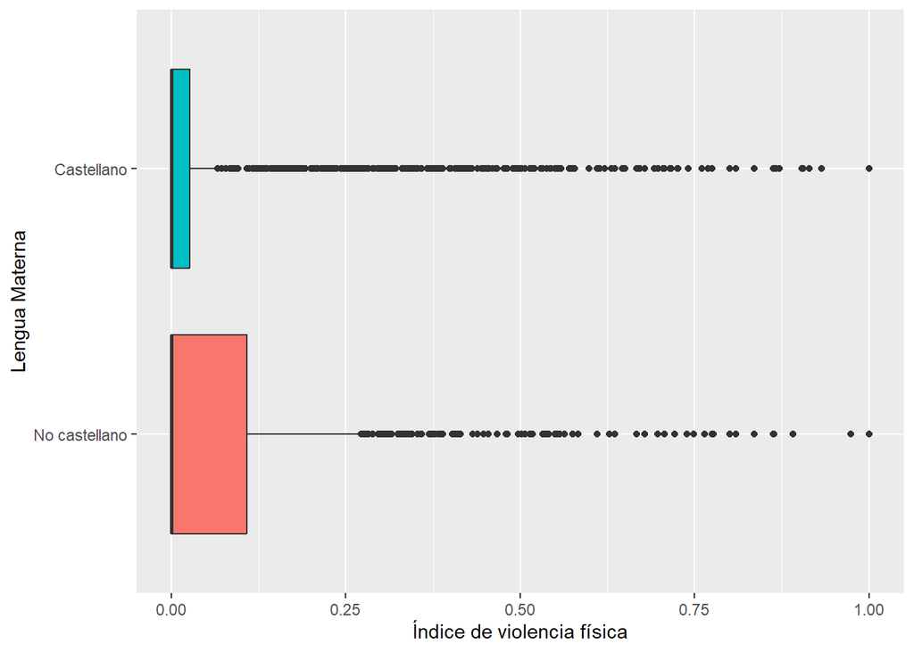

A partir de los cambios identificados, se propone como hipótesis que existe relación significativa entre los estadísticos de las variables índice de violencia física y lengua materna. A continuación, se comprobará la hipótesis propuesta:

```
##
##  Welch Two Sample t-test
##
## data:  ENDES$violencia by ENDES$lengua
## t = 14.522, df = 6718.8, p-value < 2.2e-16
## alternative hypothesis: true difference in means between group No castellano and group Castellano is not equal to 0
## 95 percent confidence interval:
##  0.03272085 0.04293357
## sample estimates:
## mean in group No castellano    mean in group Castellano
##                  0.09075946                  0.05293225
```

Con un p-valor menor a 0.05 (95% de confianza), existe evidencia suficiente para rechazar la hipótesis nula de independencia estadística entre las variables índice de violencia física y lengua materna. Por tanto, concluimos que existe una diferencia estadísticamente significativa entre las variables mencionadas.

## Relación entre índice de violencia física y lugar de residencia

A partir de la base de datos, se ha realizado una tabla cruzada de las variables índice de violencia física y lugar de residencia.

| Lugar de residencia | mean | min | max |
| --- | --- | --- | --- |
| Rural | 0.07 | 0 | 1 |
| Urbano | 0.06 | 0 | 1 |

A partir de la tabla, se puede observar que el índice de violencia varía según el lugar de residencia de la encuestada al presentarse medias distintas en los lugares de residencia. Se observa que la residencia urbana presenta una menor media (0.06) a comparación de la residencia rural (0.07). A partir de este estadístico, se podría considerar que en la residencia urbana se presenta un menor índice de violencia física. En relación a los mínimos y máximos, estos se mantienen iguales entre las dos residencias.

### Gráfico:

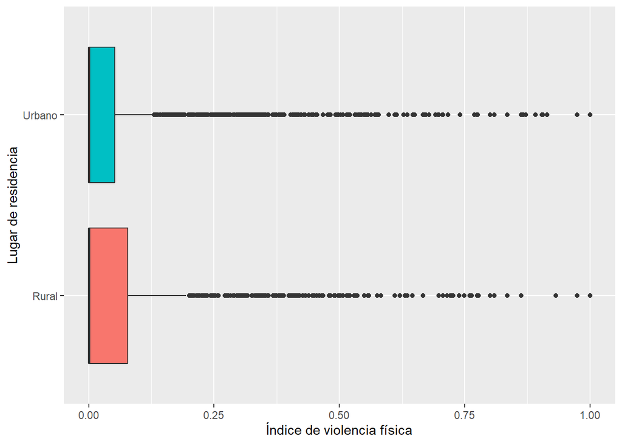

A partir de los cambios identificados, se propone como hipótesis que existe relación significativa entre los estadísticos de las variables índice de violencia física y lugar de residencia. A continuación, se comprobará la hipótesis propuesta:

```
##
##  Welch Two Sample t-test
##
## data:  ENDES$violencia by ENDES$residencia
## t = 5.2228, df = 13320, p-value = 1.789e-07
## alternative hypothesis: true difference in means between group Rural and group Urbano is not equal to 0
## 95 percent confidence interval:
##  0.006691454 0.014731656
## sample estimates:
##  mean in group Rural mean in group Urbano
##           0.06881420           0.05810265
```

## Relación entre índice de violencia física e índice de riqueza

A partir de la base de datos, se ha realizado una tabla cruzada de las variables índice de violencia física e índice de riqueza.

| Índice de riqueza | mean | min | max |
| --- | --- | --- | --- |
| El más pobre | 0.07 | 0 | 1 |
| Más rico | 0.03 | 0 | 1 |
| Medio | 0.06 | 0 | 1 |
| Pobre | 0.07 | 0 | 1 |
| Rico | 0.05 | 0 | 1 |

A partir de la tabla, se puede observar que el índice de violencia física varía según el índice de riqueza al presentarse medias distintas en cada índice de riqueza. Se puede observar que el índice de violencia se reduce al aumentar el índice de riqueza. En este sentido, los índices de más pobres y pobres presentan una media más alta, 0.07 y 0,07 respectivamente. Seguido, se presenta el índice medio con una media de violencia de 0.06. Por último, el índice rico y más rico presentan las medias más bajas siendo 0.05 y 0.03, respectivamente. En relación a los máximos y mínimos, estos se mantienen iguales en los índices de riqueza.

### Gráfico:

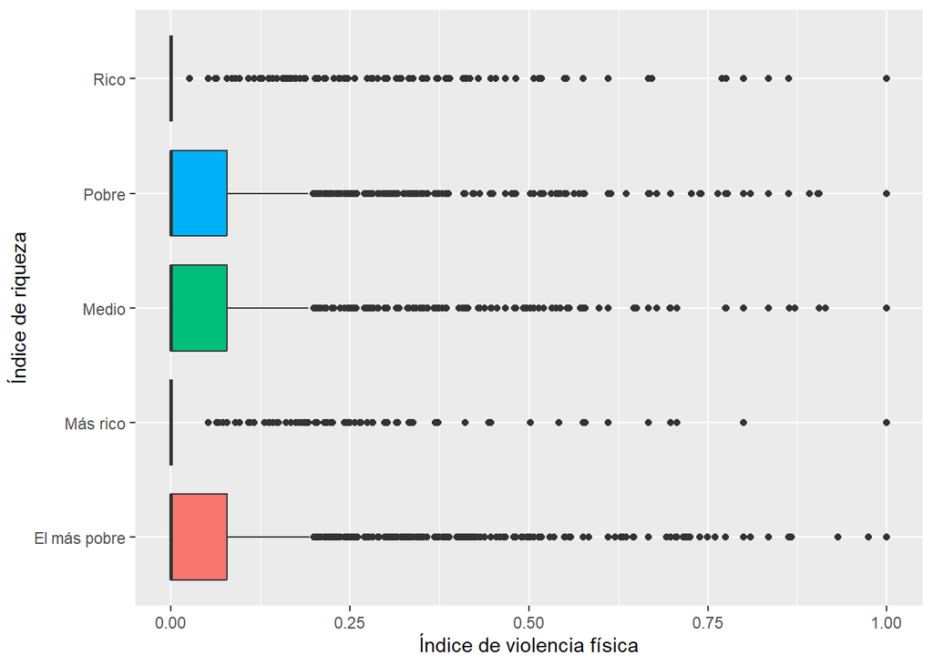

A partir de los cambios identificados, se propone como hipótesis que existe relación significativa entre los estadísticos de las variables índice de violencia física e índice de riqueza. A continuación, se comprobará la hipótesis propuesta:

```
##                Df Sum Sq Mean Sq F value Pr(>F)
## riqueza         4    3.4  0.8532   45.01 <2e-16 ***
## Residuals   21792  413.1  0.0190
## ---
## Signif. codes:  0 '***' 0.001 '**' 0.01 '*' 0.05 '.' 0.1 ' ' 1
```

Con un p-valor(>F) menor a 0.05 (95% de confianza), existe evidencia suficiente para rechazar la hipótesis nula de independencia estadística entre las variables índice de violencia física e índice de riqueza. Por tanto, concluimos que existe una diferencia estadísticamente significativa entre las variables mencionadas.

## Formulación del modelo

A continuación, se presenta la formulación del modelo de regresión lineal que nos ayudara a analizar la violencia física hacia las mujeres por parte de la pareja sentimental.

$$Y_i = B0 + B1* X1+ B2*X2 + B3*X3 + B4*X4+ B5*X5+ϵ¯$$

$Y_i$ = Índice de violencia fisica

$B0$ = Índice de violencia física cuando las variables y las categorian marquen 0

$B1$ = El cambio del índice de violencia física respecto al cambio en el nivel educativo alcanzado por la encuestada, siendo las categorías Inicial, Primario, Secundario, Superior no universitario, Superior universitario y Posgrado. Además, se presenta como categoría base la categoría Inicial.

$X1$ = Nivel educativo

$B2$ = El cambio del índice de violencia física por cada cambio unitario en la edad de la mujer encuestada (unidad = años)

$X2$ = Edad de la encuesta

$B3$ = El cambio del índice de violencia física respecto al cambio en la lengua materna de la encuestada, siendo las categorías castellano y no castellano. Además, se presenta como categoría base la categoría No castellano

$X3$ = Lengua Materna

$B4$ = El cambio del índice de violencia física respecto al cambio en el lugar de residencia de la encuestada, siendo las categorías urbano y rural. Además, se presenta como categoría base Rural

$X4$ = Lugar de residencia

$B5$ = El cambio del índice de violencia física respecto al cambio en el nivel de riqueza de la mujer encuestada, siendo las categorías El más, pobre, Pobre, Medio, Rico y El más rico. Además, se presenta como categoría base la categoría El más pobre.

$X5$ = Nivel de riqueza

$ϵ¯$ = error

## Estimacion del modelo

A continuación, se presentan los resultados del modelo de regresión lineal en el que se puede observar los efectos que tienen las variables independientes sobre la variable índice de violencia sufrida por la encuestada.

Modelo de regresión

|  | Indice de violencia |
| --- | --- |
| Intercepto | 0.031*** |
|  | (0.009) |
| Nivel educativo - Primario | -0.008 |
|  | (0.008) |
| Nivel educativo - Secundario | -0.012 |
|  | (0.008) |
| Nivel educativo - Superior no universitario | -0.028*** |
|  | (0.008) |
| Nivel educativo - Superior universitario | -0.038*** |
|  | (0.008) |
| Nivel educativo - Posgrado | -0.053*** |
|  | (0.012) |
| Lengua materna - Castellano | -0.028*** |
|  | (0.002) |
| Edad | 0.002*** |
|  | (0.000) |
| Lugar de residencia - Urbano | 0.011*** |
|  | (0.003) |
| Indice de riqueza - Pobre | -0.003 |
|  | (0.003) |
| Indice de riqueza - Medio | -0.005 |
|  | (0.004) |
| Indice de riqueza - Rico | -0.014*** |
|  | (0.004) |
| Indice de riqueza - Más rico | -0.028*** |
|  | (0.005) |
| Num.Obs. | 21797 |
| R2 | 0.037 |
| R2 Adj. | 0.037 |
| AIC | -25210.5 |
| BIC | -25098.6 |
| Log.Lik. | 12619.244 |
| F | 70.481 |
| RMSE | 0.14 |

+ p < 0.1, * p < 0.05, ** p < 0.01, *** p < 0.001

A partir de la tabla de resultado, se puede observar lo siguiente:

En la variable nivel educativo, se puede observar que alcanzar los niveles educativos Primaria y Secundaria a comparación del nivel inicial no representa una relación significativamente estadística con el índice de violencia sufrida. Sin embargo, alcanzar niveles más altos de educación (Superior no universitario, Superior universitario, Posgrado) a comparación del nivel inicial sí representa una relación estadísticamente significativa con el índice de violencia (p value < 0.05).

Es así que, a partir de esta relación significativa, se puede evidenciar el efecto negativo que representa cada una de estas categorías de nivel educativo sobre la variable índice de violencia sufrida. A continuación, se presentarán el efecto de acuerdo a cada nivel educativo:

- Cuando la mujer encuestada ha alcanzado un nivel educativo Superior no universitario a comparación del nivel educativo inicial, el índice de violencia sufrida disminuye en 0.028.
- Cuando la mujer encuestada ha alcanzado un nivel educativo Superior universitario a comparación del nivel educativo inicial, el índice de violencia sufrida disminuye en 0.038.
- Cuando la mujer encuestada ha alcanzado un nivel educativo Posgrado a comparación del nivel educativo inicial, el índice de violencia sufrida disminuye en 0.053.

En la variable lengua materna, se puede observar que hablar como lengua materna el castellano a comparación de hablar una lengua materna no castellano representa una relación estadísticamente significativa con el índice de violencia (p value < 0.05). Es así que, a partir de esta relación significativa, se puede evidenciar el efecto negativo que representa el hablar castellano sobre la variable índice de violencia sufrida. A continuación, se presentarán el efecto de acuerdo a la lengua materna:

- Cuando la mujer encuestada habla como lengua materna el castellano a comparación de hablar una lengua materna no castellana, el índice de violencia sufrida disminuye en 0.028.

En la variable edad, se puede observar que la edad representa una relación estadísticamente significativa con la variable índice de violencia (p value < 0.05). Es así que, a partir de esta relación significativa, se puede evidenciar el efecto positivo que representa la edad sobre la variable índice de violencia sufrida. A continuación, se presentarán el efecto de acuerdo a la edad de la encuestada:

- Cuando la mujer encuestada aumenta en un año su edad, el índice de violencia aumenta en 0.002.

En la variable lugar de residencia, se puede observar que residir en zonas urbanas a comparación de zonas rurales representa una relación estadísticamente significativa con el índice de violencia (p value < 0.05). Es así que, a partir de esta relación significativa, se puede evidenciar el efecto positivo que representa el lugar de residencia sobre la variable índice de violencia sufrida. A continuación, se presentarán el efecto de acuerdo al lugar de residencia de la encuestada:

- Cuando la mujer encuestada reside en zonas urbanas a comparación de residir en zonas rurales, el índice de violencia sufrido aumenta en 0.011.

En la variable índice de riqueza, se puede observar que tener índices de riqueza bajos (Pobre y Medio) a comparación de tener un índice de riqueza más pobre no representa una relación estadísticamente significativa con el índice de violencia. Sin embargo, tener índices de riqueza más altos (Rico y Más rico) a comparación de tener un índice de riqueza más pobre sí representa una relación estadísticamente significativa con el índice de violencia (p value < 0.05). Es así que, a partir de esta relación significativa, se puede evidenciar el efecto negativo que representa el índice de riqueza sobre la variable índice de violencia sufrida. A continuación, se presentarán el efecto de acuerdo al índice de riqueza que posee la encuesta:

- Cuando la mujer encuestada tiene un índice de riqueza rico a comparación de un índice de riqueza más pobre, el índice de violencia sufrida disminuye en 0.014.
- Cuando la mujer encuestada tiene un índice de riqueza más rico a comparación de un índice de riqueza más pobre, el índice de violencia sufrida disminuye en 0.028.

En relación al modelo como tal, se puede observar que la intercepción de la regresión lineal es positiva y tiene como valor 0.031. Este resultado significa que, cuando las variables propuestas para el modelo marquen cero o no tengan una categoría, el índice promedio de violencia sufrida será igual a 0.031. También, se puede observar que el modelo es válido como modelo de predicción al tener un p value menor a 0.05. Por último, de acuerdo con el R Adjusted, el modelo explica el 3.7% de la variable independiente, índice de violencia sufrida.

## Análisis de problemas de endogeneidad

Si bien se ha presentado un modelo de regresión para observar el índice de violencia, se tiene que tener en cuenta que este puede presentar ciertos problemas de endogeneidad. A continuación analizaremos el modelo de regresión a partir de los problemas de endogeneidad que presente.

1.- Variables no agregadas

En esta ocasión, se ha propuesto 5 variables que puedan explicar el índice de violencia que sufren las mujeres por parte de su pareja (edad, nivel educativo, nivel de riqueza, lengua materna y lugar de residencia). Sin embargo, se habrá podido omitir algunas variables importantes que hayan podido agregar mayor precisión en la medición de la variable índice de violencia. En este sentido, a partir de diversos estudios sobre casos peruanos, se puede observar que una variable importante en el análisis es la situación laboral de la mujer. En el estadio de Díaz y Miranda, se puede observar esta relación. Según la investigación, se presenta una fuerte relación de probabilidad que las mujeres sean violentadas por sus parejas al encontrarse activas laboralmente, especialmente, si sus esposos se encuentran desempleado (Díaz y Miranda citado en Durán, 2019). Esta última consideración es fundamental, ya que agrega otra variable al análisis de la relación violencia física y nivel educativo. Se propone que no solo debe considerar el nivel educativo y la situación laboral de la mujer, sino que esta debe ser comparada con la situación laboral y nivel educativo de la pareja. Esto se puede observar en el estudio de Mitchell (2013). El autor encontró que las mujeres con niveles educativos y mejores posiciones de empleo que los de sus esposos son más probables de sufrir violencia física por parte de ellos (Mitchell citado en Durán, 2019).  
Otra variable que puede ayudar a entender la relación entre el nivel educativo y violencia, es la variable de región. En la investigación de Castro y Rivera, se ha encontrado que se presentan altos índices de violencia contra la mujer en zonas rurales como Cuzco, Arequipa y Apurímac a comparación de las zonas urbanas. En ese sentido, el espacio geográfico, región, a partir de sus características determinadas, representa un efecto en el índice de violencia, por lo que aporta en su análisis.

2.- Error de medición

Otro problema de endogeneidad que se puede presentar es el error de medición. Este problema se puede observar en la formulación de las preguntas de la encuesta. En muchas ocasiones, las encuestas realizan preguntas muy específicas sobre los momentos de agresión que ha sufrido la mujer. Esto puede omitir otras situaciones de violencia que no han sido preguntadas o no se han podido recordar, de modo que la medición del fenómeno, índice de violencia sufrida, puede verse alterado.

3.- Causalidad inversas

A través de la literatura, se ha podido observar que en muchas ocasiones la variable de educación presenta el problema causalidad inversa. En la relación planteada, nivel educativo de la mujer y violencia sufrida por su pareja, se podría observar esta problemática. Por un lado, la relación de pareja puede controlar o manipular el acceso a la educación de su pareja. Es decir, si bien la mujer encuestada, por su contexto social, ha logrado un determinado nivel de estudio, muchas veces la pareja sentimental puede controlar y manipular que su pareja se mantenga en este nivel de escolaridad o no siga continuando sus estudios. Por otro lado, el contexto de la relación violenta en la pareja puede crear un ambiente desmotivador que no permita plantearse a la mujer encuestada una continuidad en sus estudios. Situaciones relacionadas al estrés, miedo e inseguridad pueden afectar a la encuesta, de modo que la mujer no encuentre motivación para realizar actividades como continuar con sus estudios.

## Prueba de robustez

A partir de estos problemas de endogeneidad, se ha decidido agregar una variable más al análisis para mejorar la precisión del modelo. Es así que se ha seleccionado la variable región y , por medio de esta, se realiza un modelo de efectos fijos. Este modelo nos permitirá controlar las características para que no afecten la medición de la variable dependiente, índice de violencia física sufrida.

Modelo de regresión

|  | Indice de violencia |
| --- | --- |
| Nivel educativo - Primario | -0.009 |
|  | (0.008) |
| Nivel educativo - Secundario | -0.018* |
|  | (0.008) |
| Nivel educativo - Superior no universitario | -0.037*** |
|  | (0.008) |
| Nivel educativo - Superior universitario | -0.049*** |
|  | (0.008) |
| Nivel educativo - Posgrado | -0.066*** |
|  | (0.012) |
| Lengua materna - Castellano | -0.010*** |
|  | (0.003) |
| Edad | 0.002*** |
|  | (0.000) |
| Lugar de residencia - Urbano | 0.015*** |
|  | (0.003) |
| Indice de riqueza - Pobre | -0.005 |
|  | (0.003) |
| Indice de riqueza - Medio | -0.005 |
|  | (0.004) |
| Indice de riqueza - Rico | -0.013** |
|  | (0.004) |
| Indice de riqueza - Más rico | -0.026*** |
|  | (0.005) |
| Num.Obs. | 21797 |
| R2 | 0.031 |
| R2 Adj. | 0.029 |
| AIC | -25472.6 |
| BIC | -25368.7 |
| RMSE | 0.13 |

+ p < 0.1, * p < 0.05, ** p < 0.01, *** p < 0.001

A partir de la tabla de resultado, se puede observar lo siguiente:

En la variable nivel educativo, en el modelo controlado por las características de la región, se puede observar que alcanzar el nivel educativo Primario a comparación del nivel inicial no representa una relación significativamente estadística con el índice de violencia sufrida. Sin embargo, alcanzar niveles más altos de educación (Secundario, Superior no universitario, Superior universitario, Posgrado) a comparación del nivel inicial sí representa una relación estadísticamente significativa con el índice de violencia (p value < 0.05).

Es así que, a partir de esta relación significativa, se puede evidenciar el efecto negativo que representa cada una de estas categorías de nivel educativo sobre la variable índice de violencia sufrida. A continuación, se presentarán el efecto de acuerdo a cada nivel educativo:

- En el modelo controlado por las características de cada región, cuando la mujer encuestada ha alcanzado un nivel educativo Secundario a comparación del nivel educativo inicial, el índice de violencia sufrida disminuye en 0.018.
- En el modelo controlado por las características de cada región, cuando la mujer encuestada ha alcanzado un nivel educativo Superior no universitario a comparación del nivel educativo inicial, el índice de violencia sufrida disminuye en 0.037.
- En el modelo controlado por las características de cada región, cuando la mujer encuestada ha alcanzado un nivel educativo Superior universitario a comparación del nivel educativo inicial, el índice de violencia sufrida disminuye en 0.049.
- En el modelo controlado por las características de cada región, cuando la mujer encuestada ha alcanzado un nivel educativo Posgrado a comparación del nivel educativo inicial, el índice de violencia sufrida disminuye en 0.066.

En la variable edad, en el modelo controlado por las características de la región, se puede observar que la edad representa una relación estadísticamente significativa con la variable índice de violencia (p value < 0.05). Es así que, a partir de esta relación significativa, se puede evidenciar el efecto positivo que representa la edad sobre la variable índice de violencia sufrida. A continuación, se presentarán el efecto de acuerdo a la edad de la encuestada:

- En el modelo controlado por las características de la región, cuando la mujer encuestada aumenta en un año su edad, el índice de violencia aumenta en 0.002.

En la variable lugar de residencia, en el modelo controlado por las características de la región, se puede observar que residir en zonas urbanas a comparación de zonas rurales representa una relación estadísticamente significativa con el índice de violencia (p value < 0.05). Es así que, a partir de esta relación significativa, se puede evidenciar el efecto positivo que representa el lugar de residencia sobre la variable índice de violencia sufrida. A continuación, se presentarán el efecto de acuerdo al lugar de residencia de la encuestada:

- En el modelo controlado por las características de la región, cuando la mujer encuestada reside en zonas urbanas a comparación de residir en zonas rurales, el índice de violencia sufrido aumenta en 0.015.

En la variable índice de riqueza, en el modelo controlado por las características de la región, se puede observar que tener índices de riqueza bajos (Pobre y Medio) a comparación de tener un índice de riqueza más pobre no representa una relación estadísticamente significativa con el índice de violencia. Sin embargo, tener índices de riqueza más altos (Rico y Más rico) a comparación de tener un índice de riqueza más pobre sí representa una relación estadísticamente significativa con el índice de violencia (p value < 0.05). Es así que, a partir de esta relación significativa, se puede evidenciar el efecto negativo que representa el índice de riqueza sobre la variable índice de violencia sufrida. A continuación, se presentarán el efecto de acuerdo al índice de riqueza que posee la encuesta:

- En el modelo controlado por las características de la región, cuando la mujer encuestada tiene un índice de riqueza rico a comparación de un índice de riqueza más pobre, el índice de violencia sufrida disminuye en 0.013.
- En el modelo controlado por las características de la región, cuando la mujer encuestada tiene un índice de riqueza más rico a comparación de un índice de riqueza más pobre, el índice de violencia sufrida disminuye en 0.026.

En relación al modelo como tal, se puede observar que el modelo es válido como modelo de predicción al tener un p value menor a 0.05. También, de acuerdo con el R Adjusted, el modelo explica el 2.9% de la variable independiente, índice de violencia sufrida.

## Comparación de los modelos

A partir de la propuesta del segundo modelo, se puede observar cambios sobre los efectos de cada variable independiente en relación al primer modelo propuesto.

## Conclusiones

En conclusión, el modelo de regresión propuesto ayuda a comprender el análisis del índice de violencia que puede sufrir la mujer encuestada. Es así que las variables propuestas en el modelo presentan una relación significativa con el índice de violencia sufrido. Es decir, aportan a su entendimiento.

Sumado a esto, se puede observar que, al construir el modelo a partir de variables independientes categóricas, se aporta mayor precisión en la medición del índice de violencia. Es así que se puede observar cómo los efectos sobre la variable dependiente aumentan de acuerdo con cada categoría. Por ejemplo, se observa que el índice de violencia disminuye cuando la persona entrevistada alcanza niveles más altos de nivel educativo. De este modo, se puede considerar que la educación contribuye a una menor probabilidad de índice de violencia. Este patrón de aumento en el efecto sobre la variable dependiente, también, se puede evidenciar en la variable índice de riqueza. Se observa que el índice de violencia sufrida disminuye constantemente cuando la mujer encuestada presenta un índice de riqueza más alto. En este sentido, índices de riquezas altos disminuyen la probabilidad de que la mujer encuestada sufra violencia física.

En relación a las otras variables propuestas, en el caso de la variable lengua materna, se puede evidenciar que el hablar como lengua materna el castellano reduce la probabilidad de sufrir violencia física por parte de la pareja. Este resultado puede deberse a distintas situaciones. Por un lado, el hablar castellano puede permitir a la mujer acceder o facilitar realizar una denuncia en caso de una primera situación de abuso. Por otro lado, esta lengua, también, permite el fácil acceso a los sistemas de educación por lo que aumentaría el nivel educativo, lo cual disminuye el índice de violencia que pueda sufrir la mujer.

En el caso de la variable lugar de residencia, se puede evidenciar que residir en zonas urbanas aumenta la probabilidad de sufrir violencia por parte de la pareja. Este resultado se presenta interesante, ya que, en la literatura, se propone que las zonas urbanizadas permiten facilitan el acceso a servicios y presentan menores niveles de precariedad, por lo que ayudarían a disminuir los índices de violencia. En ese sentido, el resultado presentado permitiría un nuevo análisis sobre el efecto de residir en zonas urbanas en una mayor probabilidad de sufrir índices de violencia. En el caso de la variable edad, se puede evidenciar que cumplir más años aumenta la probabilidad de sufrir violencia por parte de la pareja. Este resultado puede deberse a que cumplir más años de edad puede permitir a la mujer experimentar más relaciones sentimentales en las cuales se pueda sufrir situaciones violentas.

Por último, en relación al segundo modelo propuesto, se puede evidenciar que, al controlar las características de cada región, variables como nivel educativo y lugar de residencia aumentan sus efectos sobre la variable dependiente. En el caso de lengua materna y índice de riqueza, el efecto sobre la variable independiente disminuye a comparación del primer modelo.

Como discusión final, la presente investigación me ha permitido comprender más a profundidad los índices altos de violencia que sufren las mujeres en el Perú. Es así que he podido comprender cómo la educación es un eje fundamental para el desarrollo y empoderamiento de la mujer, ya que le permite soltar lazos de dependencia en relación con su pareja. De esta forma, al presentarse como un eje fundamental, considero necesario la importancia de una mayor facilidad de acceso a recursos educativos. Por último, considero que el análisis de datos de la presente encuesta presenta un rol importante, ya que, a través de estos, se ha logrado identificar un problema y una posible solución. Esto evidencia la necesidad constante de desarrollar y mejorar estas herramientas para el uso de la ciencias sociales.

## Bibliografía

Castro, R. J., & Rivera, R. (2017). Mapa de la violencia contra la mujer: La importancia de la familia. Rev Investig. 2015; 6: 101-25. Acceso, 2(03).

Durán Fernández, R. L. (2019). ¿ Más educadas, más empoderadas? Complementariedad entre escolaridad y empleo en la probabilidad de violencia doméstica contra las mujeres en el Perú.